# Tableau de suivi

JcB

10/07/2014

Ce document recense le suivi des RPU.

Remplacer **dx** par le noms des données à analyser. Par défaut *dx* fait référence aux données de l’année. **data** est un nom générique pour l’ensemble des calculs.

```r
load("~/Documents/Resural/Stat Resural/RPU_2014/rpu2014d0111_provisoire.Rda")
data <- dx

library("lubridate")
anc <- year(data$ENTREE[1])
```

# Novembre 2014

## Haguenau

```r
# tois les rpu de haguenau
hag <- dx[dx$FINESS == "Hag",] # dx = rpu2014d0111_provisoire
# rpu peédiatriques
ped.hag <- hag[hag$AGE < 18,]
rpu.hag <- tapply(as.Date(hag$ENTREE), month(as.Date(hag$ENTREE)), length)
rpu.ped.hag <- tapply(as.Date(ped.hag$ENTREE), month(as.Date(ped.hag$ENTREE)), length)
rpu.ped.hag * 100 / rpu.hag
```

```
##        1        2        3        4        5        6        7        8
## 10.97520 12.19512 14.42720 15.27963 14.73142 15.50095 28.38861 27.98032
##        9       10       11
## 34.23631 32.91071 34.58647
```

[output not shown]

## Wissembourg

Envoi d’un fichier XML avec les données du 1er janvier au 19 novembre 2014. Fichier transformé en csv et archivé dans /home/jcb/Documents/Resural/Stat Resural/Archives_Sagec/RPU2014_Wissembourg. Reste la maj dans le fichier maître à faire: supprimer les enregistrements de wissembourg entre le 1er javier et le 19 novembre et les remplacer par des derniers.

# Octobre 2014

L’évènement du mois est le passage en production du nouvelle méthodologie des HUS (développée par mr Lorenz) permettant une transmission exhaustive des RPU. La bascule se fait pour les données du 13 octobre:

```
 rj <- rpu_jour("2014-10-13")
 d <- rj[rj$FINESS=="Hus",]
tapply(as.Date(d$ENTREE), as.Date(d$ENTREE), length)

2014-10-06 2014-10-07 2014-10-08 2014-10-09 2014-10-10 2014-10-11 2014-10-12
       139        415        422        425        465        436        462
```

Deux FINESS nouveaux sont introduits: NHC et HTP. Pour l’instant les deux FINESS sont fusionnés en un seul.

# Août 2014

Incorporation des fichiers de Juillet. Pas de problèmes notables sauf Diaconat Strasbourg qui n’envoie pas de données Pb de serveur, je ne reçoit pas les RPU du diaconat -> relancer Nold Parser XML terminé le 15/8. Voir avec Nold pour lasuite

# Septembre 2014

Le fichier **rpu2014d08.Rda** est créé à partir des fichiers .csv allant du 8/8/2014 au 7/9/2014. Un trou à rattrapper pour Altkirch à partir du 20/8.

```r
h <- function(x){head(x,20)}
tapply(data$MOTIF, data$FINESS, h)
```

```
## $`3Fr`
##  [1] NA NA NA NA NA NA NA NA NA NA NA NA NA NA NA NA NA NA NA NA
##
## $Alk
##  [1] NA      "M7961" NA      NA      NA      NA      "R103"  "T119"
##  [9] "H920"  NA      "K089"  "T139"  "R529"  "L039"  NA      "T139"
## [17] "R51"   "I100"  "T139"  "R060"
##
## $Col
##  [1] "une intoxication \xe9thylique"
##  [2] "un malaise avec PC"
##  [3] "une br\xfblure"
##  [4] "des douleurs abdominales"
##  [5] "une hyperthermie depuis moins de 24 h ;"
##  [6] "une br\xfblure oculaire"
##  [7] "une br\xfblure"
##  [8] "une hyperthermie depuis moins de 24 h ;"
##  [9] "une plaie ; des acouph\xe8nes"
## [10] "une intoxication \xe9thylique"
## [11] "des palpitations"
## [12] "une confusion et(ou) d\xe9sorientation temp"
## [13] "un malaise avec PC ; des convulsions"
## [14] "une toux et un encombrement ; un vomisse"
## [15] "une \xe9ruption cutan\xe9e"
## [16] "une intoxication \xe9thylique"
## [17] "CALCUL BILIAIRE"
## [18] "une chute m\xe9canique ; un traumatisme cr\xe2"
## [19] "une r\xe9quisition pour certificat m\xe9dical"
## [20] "une douleur dentaire"
##
## $Dia
##  [1] "R002" "T300" "T009" "T300" "T009" "T159" "T139" "R104" "T119" "K089"
## [11] "R11"  "S008" "T009" "R55"  "S008" "R074" "T009" "K089" "S21"  "H571"
##
## $Geb
##  [1] NA NA NA NA NA NA NA NA NA NA NA NA NA NA NA NA NA NA NA NA
##
## $Hag
##  [1] "Asthme, sans pr\xe9cision"
##  [2] "Troubles mentaux et du comportement li\xe9s \xe0 l'utilisation d'alcool : intoxication aigu\xeb"
```

[output cut: 51 more lines]

```
## $Ros
##  [1] NA     NA     "T119" NA     NA     NA     NA     NA     NA     NA
## [11] "T009" "T009" "T009" "T009" NA     NA     NA     NA     "T009" NA
##
## $`680020096`
## NULL
##
## $Ane
##  [1] NA                   NA                   NA
##  [4] NA                   NA                   NA
##  [7] NA                   NA                   NA
## [10] NA                   NA                   "Douleur thoracique"
## [13] NA                   NA                   NA
## [16] NA                   NA                   "Traumatisme coude"
## [19] NA                   NA
```

## pas de saisie

Ste Anne ? 1 seule réponse en novembre: “U359**"

## pas conforme

Sélestat Colmar

## Conforme:

Mulhouse Se Odile Roosvelt Saverne: ok mais bcp de non réponses Wissembourg Diaconat Mulhouse: sp Diaconat Strasbourg Guebwiller Haguenau HUS 3Fr (complétude = 2 %…) Altkirch (complétude = 17 %…)

## suivi de la conformité

c3f <- d11[d11$FINESS == “3Fr”, “MOTIF”] mean(is.na(c3f)) c3f[!is.na(c3f)]

alk <- d11[d11$FINESS == “Alk”, “MOTIF”] mean(is.na(alk)) alk[!is.na(alk)]

ane <- d11[d11$FINESS == “Ane”, “MOTIF”] mean(is.na(ane)) ane[!is.na(ane)]

## suivi de la complétude

Il faut corriger DESTINATION et ORIENTATION: si MODE_SORTIE = Domicile, alors les 2 items ne peuvent être remplis et se voient attribuer la valeur NA, ce qui provoque une erreur dans le décompte de ces 2 items. Pour éviter cela, on leur attribue la valeur “domicile” si MODE_SORTIE = Domicile.

```r
data$DESTINATION[data$MODE_SORTIE == "Domicile"] <- "Domicile"
data$ORIENTATION[data$MODE_SORTIE == "Domicile"] <- "Domicile"
pIsNa <- function(x){apply(is.na(x),2,mean)} # mean(is.na(x)) = % ne non réponses
a <- unique(data$FINESS) # liste des établissements
for(i in a){print(i); x <- pIsNa(data[data$FINESS==i,]); print((1-x)*100) }
```

```
## [1] "Sav"
##            id   CODE_POSTAL       COMMUNE   DESTINATION            DP
##    100.000000    100.000000    100.000000     18.946038      1.742119
##        ENTREE       EXTRACT        FINESS       GRAVITE   MODE_ENTREE
##    100.000000    100.000000    100.000000     57.268705    100.000000
##   MODE_SORTIE         MOTIF     NAISSANCE   ORIENTATION    PROVENANCE
##     88.101446     48.775381    100.000000     17.658213      3.705459
##          SEXE        SORTIE     TRANSPORT TRANSPORT_PEC           AGE
##    100.000000     88.780912      0.000000      0.505649    100.000000
## [1] "Sel"
##            id   CODE_POSTAL       COMMUNE   DESTINATION            DP
##     100.00000     100.00000     100.00000      19.98637      96.37704
##        ENTREE       EXTRACT        FINESS       GRAVITE   MODE_ENTREE
##     100.00000     100.00000     100.00000      97.65550     100.00000
##   MODE_SORTIE         MOTIF     NAISSANCE   ORIENTATION    PROVENANCE
##      99.99198      98.28471     100.00000      19.98637     100.00000
##          SEXE        SORTIE     TRANSPORT TRANSPORT_PEC           AGE
##     100.00000      97.13049      99.77156     100.00000     100.00000
## [1] "Dia"
##            id   CODE_POSTAL       COMMUNE   DESTINATION            DP
##   100.0000000   100.0000000   100.0000000    18.4269486     0.4716796
##        ENTREE       EXTRACT        FINESS       GRAVITE   MODE_ENTREE
##   100.0000000   100.0000000   100.0000000    97.4529303    99.3710939
##   MODE_SORTIE         MOTIF     NAISSANCE   ORIENTATION    PROVENANCE
##    97.4332770    96.8672615   100.0000000    13.4821744    99.3317873
##          SEXE        SORTIE     TRANSPORT TRANSPORT_PEC           AGE
##   100.0000000   100.0000000    99.9882080    97.4607916   100.0000000
## [1] "Geb"
##            id   CODE_POSTAL       COMMUNE   DESTINATION            DP
##   100.0000000   100.0000000   100.0000000     7.7731693    99.0989703
##        ENTREE       EXTRACT        FINESS       GRAVITE   MODE_ENTREE
##   100.0000000   100.0000000   100.0000000    99.3492563    85.9625286
##   MODE_SORTIE         MOTIF     NAISSANCE   ORIENTATION    PROVENANCE
##    87.8504005    40.2102403   100.0000000     3.9831236     0.3790046
##          SEXE        SORTIE     TRANSPORT TRANSPORT_PEC           AGE
##   100.0000000    99.3492563    98.9559497    83.4882723   100.0000000
## [1] "Mul"
##            id   CODE_POSTAL       COMMUNE   DESTINATION            DP
##     100.00000     100.00000      99.97640      14.29246      79.48077
##        ENTREE       EXTRACT        FINESS       GRAVITE   MODE_ENTREE
```

[output cut: 80 more lines]

```
##        ENTREE       EXTRACT        FINESS       GRAVITE   MODE_ENTREE
##     100.00000     100.00000     100.00000      85.32819      99.30502
##   MODE_SORTIE         MOTIF     NAISSANCE   ORIENTATION    PROVENANCE
##      80.11583      92.27799     100.00000       0.00000       0.00000
##          SEXE        SORTIE     TRANSPORT TRANSPORT_PEC           AGE
##     100.00000      83.93822      94.05405      94.05405     100.00000
## [1] "Ane"
##            id   CODE_POSTAL       COMMUNE   DESTINATION            DP
##   100.0000000   100.0000000   100.0000000     0.9073119     0.0000000
##        ENTREE       EXTRACT        FINESS       GRAVITE   MODE_ENTREE
##   100.0000000   100.0000000   100.0000000    41.6651841   100.0000000
##   MODE_SORTIE         MOTIF     NAISSANCE   ORIENTATION    PROVENANCE
##    15.7267390    40.7222914   100.0000000     0.4269703   100.0000000
##          SEXE        SORTIE     TRANSPORT TRANSPORT_PEC           AGE
##   100.0000000    96.5130760    42.0743640     0.0000000   100.0000000
```

```r
# la fonction qui suit automatise la tâche et retourne l'inverse de la fonction h cad le % de réponses pour l'item, sous forme de dataframeun dataframe:
complet <- function(hop, data){
  j = 0;
  for(i in hop){
    x <- pIsNa(data[data$FINESS==i,]);
    x <- (1-x)*100; # inverse de la fonction
    j = j+1
    if(j == 1)
      t = x
    else
      t = rbind(t,x)
  }
  t <- data.frame(hop,t)
  return(t)
}

# dataframe des complétudes par rubrique et par finess
q <- complet(a,data)
# fonction auxiliaire qui retourne la moyenne d'un vecteur x, arrondi à 2 décimales
arrondi <- function(x){round(mean(x, na.rm = TRUE), 2)}
# application: pour chaque rubrique calcule la moyenne de l'ensemble des Finess (les rubriques sont en colonnes)
apply(q[-1], 2, arrondi)
```

```
##            id   CODE_POSTAL       COMMUNE   DESTINATION            DP
##        100.00        100.00         99.99         15.27         54.27
##        ENTREE       EXTRACT        FINESS       GRAVITE   MODE_ENTREE
##        100.00        100.00        100.00         83.23         93.69
##   MODE_SORTIE         MOTIF     NAISSANCE   ORIENTATION    PROVENANCE
##         81.42         63.10        100.00         12.22         53.75
##          SEXE        SORTIE     TRANSPORT TRANSPORT_PEC           AGE
##        100.00         90.79         74.35         65.73        100.00
```

**q** est un dataframe de 15 lignes et 21 colonnes

TODO: faire des radars: les établissements comme rayons et les rubriques comme intitulé du graphe.

Remarque pour 2013: on réduit de façon importante les NA sur ces 2 rubriques.

```
load("../RPU_2013/rpu2013d0112.Rda")
d1$DESTINATION <- as.character(d1$DESTINATION)
d1$DESTINATION[d1$MODE_SORTIE == "Domicile"] <- "Domicile"
d1$DESTINATION <- as.factor(d1$DESTINATION)
summary(d1$DESTINATION)
mean(is.na(d1$DESTINATION))

d1$ORIENTATION <- as.character(d1$ORIENTATION)
d1$ORIENTATION[d1$MODE_SORTIE == "Domicile"] <- "Domicile"
d1$ORIENTATION <- as.factor(d1$ORIENTATION)
summary(d1$ORIENTATION)
mean(is.na(d1$ORIENTATION))

Domicile      HAD      MCO      PSY      SLD      SSR     NA's
  223155        5    71522     1173       27      102    48089
[1] 0.1397639

CHIR Domicile    FUGUE      HDT       HO      MED     OBST      PSA      REA      REO       SC       SI     UHCD     NA's
7738   223155        1      110       29    18449       96       52     1025       44     1420     1366    32169    58419
[1] 0.1697866
```

## Incohérence destination et mode de sortie

On ne peut pas avoir simultanément MODE_SORTIE = Domicile et DESTINATION = MCO. Par exemple pour sptembre 2014:

```
data <- dx
table(data$DESTINATION, data$MODE_SORTIE)

      Domicile Mutation Transfert
  MCO       45     6446       360
  PSY        0       35        50
  SSR        0        6         8
```

Il y a 45 destinations incohérentes. Elle correspondent à Ste Anne et aux HUS:

```
a <- data[data$MODE_SORTIE=="Domicile" & data$DESTINATION=="MCO" & !is.na(data$DESTINATION) & !is.na(data$MODE_SORTIE),]
table(a$FINESS)
```

# Juillet 2014

Le tableau de suivi du mois de Juin a révélé un grand nombre de RPU manquants. Ceci a pu être rapporté à un problème sur le serveur des HUS. Mr Nold a fait parvenir le 9/7/2014 un fichier .sql corrigé qui reprend tous les RPU du mois de juin. Ce fichier est intitulé **rpu_2014_06_dump.sql.gz**. Il est archivé sur le disque Toshiba dans le dossier **RPU Juin 2014 Correctif** qui annule et remplace les données quotidienne du mois de juin 2014.

Ce fichier est copié dans le dossier **stat_resural/Archives_Sagec/dataQ** et renommé **rpu_2014-06-00_dump.sql** pour être traité. L’original se trouve dans le dossier **stat_resural/Archives_Sagec/dataQ/ArcjivesSQL/Juin_2014_sql/Juin_2014_corrige**

Ce fichier a été traité de la façon suivante:

```
source("Preparation/RPU Quotidiens/quot_utils.R")
# tranasformation du fichier .sql en dataframe
rj <- rpu_jour("2014-06-00")
# correctif car le fichier initial comporte des données du 1er juillet
a <- rj[as.Date(rj$ENTREE) < "2014-07-01",]
max(as.Date(a$ENTREE))
# vérification de l'exhaustivité
table(as.Date(a$ENTREE), a$FINESS)
# sauvegarde sous forme de fichier R
d06 <- a
rm(a, rj)
save(d06, file = "rpu2014d06.Rda")
# fusion avec les données des mois précédents
load("~/Documents/Resural/Stat Resural/RPU_2014/rpu2014d0105.Rda")
dx <- rbind(dx, d06)
save(dx, file = "rpu2014d0106.Rda")
# contrôle des dates
min(as.Date(dx$ENTREE))
max(as.Date(dx$ENTREE))
# Tableau des RPU par FINESS avec transformation du tableau croisé en dataframe. Noter l'emploi de la méthode as.data.frame.matrix qui conserve le tableau (si on utilise as.data.frame le résultat ne corresnd pas du tout aux attentes!)
rpu <- as.data.frame.matrix(table(as.Date(dx$ENTREE), factor(dx$FINESS)))
somme.lignes <- rowSums(rpu)
```

Le résultats final:

- 193.641 RPU au 30 juin
- manque SOS mains Strasbourg et Thann

# Juin 2014

Au 6/6 Ste Anne n’émet rien => vérifier

## Essai d’utilisation de Xts

On forme une table de contingence en croisant la date d’entrée et le Finess. Le croisement donne le total des RPU par jour pour un SU. Le tableau est transformé en dataframe par **as.data.frame.matrix**. La transformation en dataframe permet de préserver la nature des colonnes. On crée une colonne **date** correspondant à chaque jour du mois que l’on ajoute au dataframe et cette nouvelle colonne est mise au format ‘Date’. C’est elle qui servira d’index à l’objet xts. On crée également une colonne total qui est ajoutée au dataframe.

Le dataframe est transformé en objet **xts** qui peut être plotté. On ajoute la moyenne mobile avec **rollappy** (j’ai essayé avec rollmean mais j’ai une erreur ?)

```r
library(xts)
```

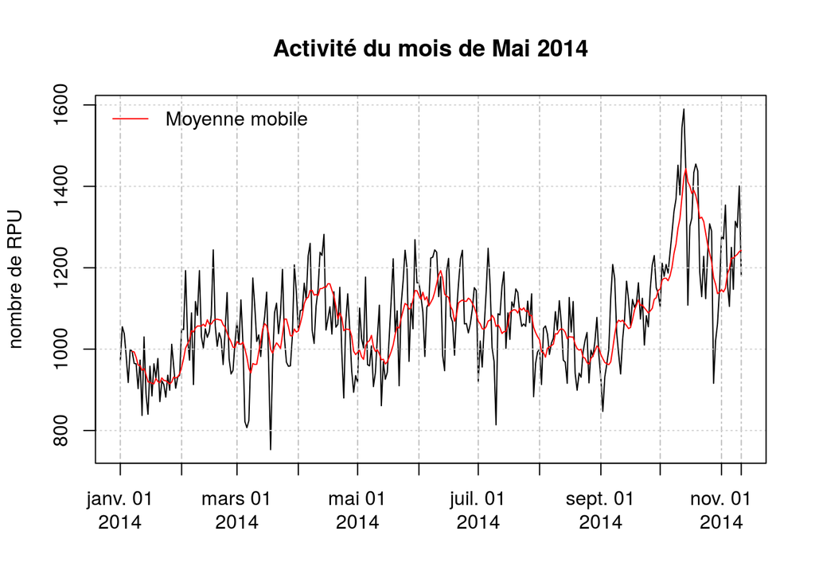

```r
data <- dx

t <- table(as.Date(data$ENTREE), data$FINESS)
date <- rownames(t)
a <- as.data.frame.matrix(t)
a <- cbind(a, date)
a$date <- as.Date(a$date)
a$total <- rowSums(a[,1:14])
ts <- xts(a, order.by = a$date)

anc <- year(data$ENTREE[1])
plot(ts$total, main= paste0("Activité du mois de Mai ", anc), ylab="nombre de RPU", minor.ticks = FALSE)

lines(rollapply(ts$total, 7, mean), col="red")
legend("topleft", legend="Moyenne mobile", col="red", lty=1, bty="n")
```

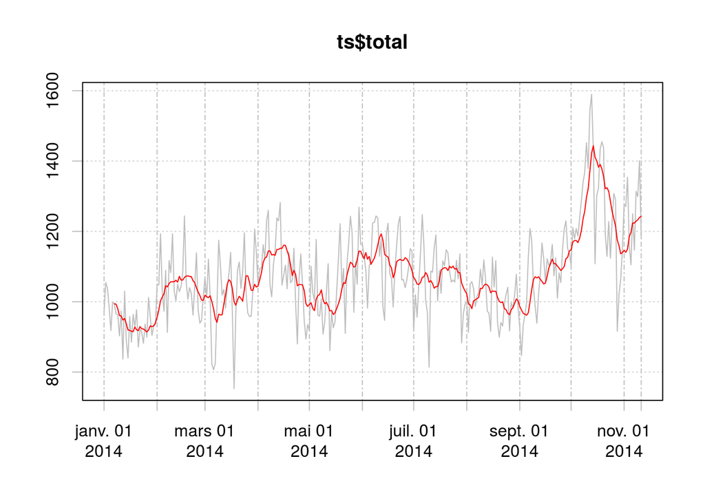

```r
plot(ts$total,minor.ticks=FALSE, col = "gray")
lines(rollapply(ts$total, 7, mean), col="red")
```

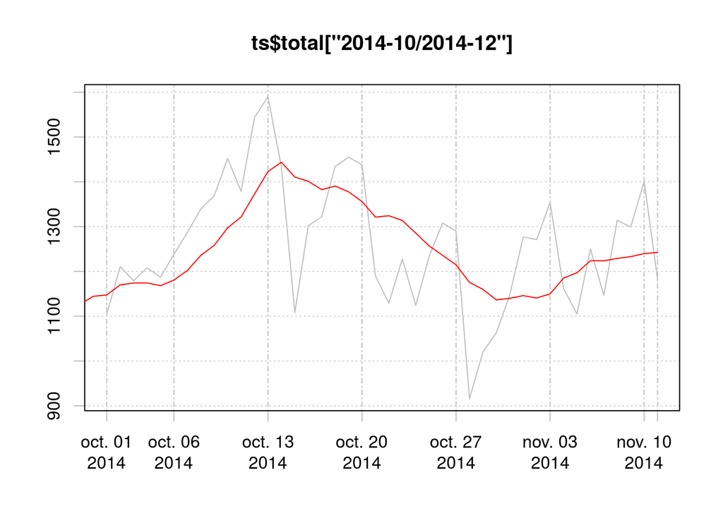

```r
# essai d'agrandissement de la fenêtre:
plot(ts$total["2014-10/2014-12"],minor.ticks=FALSE, col = "gray")
lines(rollapply(ts$total["2014-09/2014-12"], 7, mean), col="red")
```

fonction dérivée

A partir du fichier habituel des RPU retourne un objet xts ayant autant de colonnes qu’il y a de SU dans d plus 2 colonnes supplémentaires: - date de type ‘Date’ qui sert d’index à xts - total nombre total de RPU par jour

d données RPU

rpu2xts <- function(d){ library(xts) t <- table(as.Date(d$ENTREE), d$FINESS) date <- rownames(t) a <- as.data.frame.matrix(t) a <- cbind(a, date) a$date <- as.Date(a$date) a$total <- rowSums(a[,1:14]) ts <- xts(a, order.by = a$date) ts }

## Sauvegarde de données de juin

date1 <- “2014-06-08” date2 <- “2014-06-18” p <- seq(as.Date(date1), as.Date(date2), 1) for(i in 1:length(p)){ dx <- rpu_jour(p[i]) } dx <- assemble(comment = FALSE) min(as.Date(dx$ENTREE)) table(as.Date(dx$ENTREE), dx$FINESS) d06 <- dx save(d06, file = “rpu2014d06_Provisoire.Rda”)

# C3F - Mai 2014

A partir du 16 mai 2014 la clinique des 3 frontières passe au n°Finess **680020096**. Ce changement provoque une erreur dans le fichier transmis par Mr Nold car les données de la clinique apparaissent deux fois: une fois sous “3Fr” et une fois sous “680020096”. Les données sont corrigées jusqu’au 19/05 inclus. Anomalie signalée le 31/05/2014 , en attente.

```
c3f <- data[as.Date(data$ENTREE) >= "2014-05-16" & as.Date(data$ENTREE) <= "2014-05-23" & data$FINESS == "3Fr",]
c3fo <- c3f[order(c3f$ENTREE),]
c3 <- c3fo[1,]
seq <- seq(3, nrow(c3fo), by=2)
for(i in seq){c3 <- rbind(c3, c3fo[i,])}
data_saufc3f <- data[data$FINESS != "3Fr",]
data_3fr <- data[data$FINESS == "3Fr",]
data_3fr_sauf_doublons <- data_3fr[as.Date(data_3fr$ENTREE) < "2014-05-16" | as.Date(data_3fr$ENTREE) > "2014-05-23",]
data_corrige <- rbind(data_saufc3f, data_3fr_corrige)
table(as.Date(data_corrige$ENTREE), data_corrige$FINESS)
data <- data_corrige
save(data, file="rpu2014data.Rda")
load("rpu2014d0104.Rda")
dx <- rbind(a, data)
save(dx, file="rpu2014d0105.Rda")
```

CCL: les données du mpois de Mai 2014 sont ‘propres’ à la date du 12 juin 2014.

Anomalies du mois de mai:

- Ste Anne a fait unessai du 12 au 16 mai, et semle être passé en production depuisle 28 mai 2014. A vérifier en juin.
- CH Alkirch: toujours des ratées dans la transmission: 1, 4, 11, 27, 29 mai
- CHM: 9, 10, 22 nb anormalement bas de assages
- Roosvelt: 13 mai nnb de RPU < 10
- CH Selestat: 13, 15, 16,17 moins de 5 RPU
- 158 346 RPU au 31 mai 2014. Comparaison avec 2013:

```
load("../RPU_2013/rpu2013d0112.Rda")
d_2013_au31mai <- d1[as.Date(d1$ENTREE) < "2013-06-01",]
nrow(d_2013au31mai)

# 137 612
```

soit **20734** RPU de plus soit environ 400.000 RPU en 2014.

Les chiffres de référence de passages figurent dans le fichier SAE 2013. La somme des passages est égale à **493321**, non comptés les SOS mains.

Au 11/11/2014, les sos mains représentent 8762 passages:

```r
m1 <- dx[dx$FINESS == "Dts", "ENTREE"]
m2 <- dx[dx$FINESS == "Ros", "ENTREE"]
length(m1) + length(m2)
```

```
## [1] 8762
```

```r
n.rpu.su <- nrow(dx) - length(m1) - length(m2)
n.rpu.su
```

```
## [1] 341589
```

Rajouter:

```
Résumé d'activité
Radar
```